# Praca domowa 2

Adam Ryski

## Dane

Dane wykorzystane w Pracy domowej 2 opisują wycenę nieruchmości. Każda obserwacja jest pewną nieruchmością, która posiada informacje takie jak powierzchnia, liczba pokoi, liczba łazienek i wiele więcj. Opis wszystkich kolumn w pliku `README.md`.

## Zadanie 1

Jak wygląda rozkład ceny nieruchomości w poszczególnych kodach pocztowych na przestrzeni lat? Rozważamy kody pocztowe, które mają więcej niż 280 posiadłości.

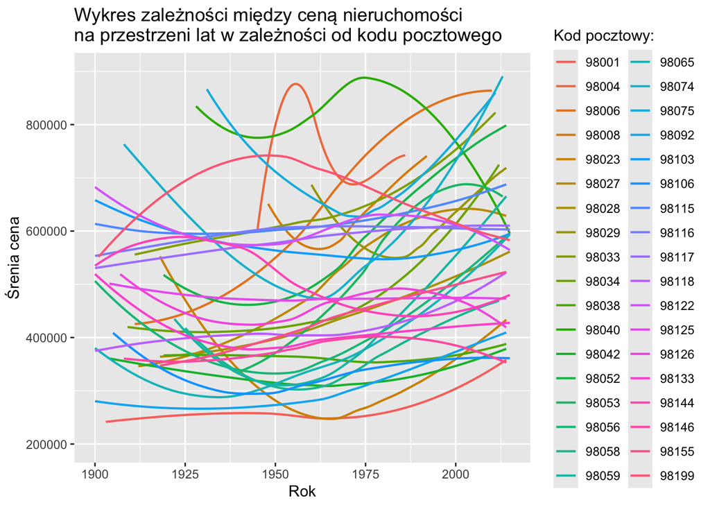

```r
# Jako, że biorąc pod uwagę date - datę sprzedaży mamy dostępne tylko dwa lata, zakładam, że jednak chodziło o rok wybudowania.
ex1 <- df %>% group_by(zipcode) %>% summarise(zipcode_count = n()) %>% left_join(df) %>% filter(zipcode_count > 280) %>% select(yr_built, price, zipcode) %>% group_by(yr_built, zipcode) %>% summarise(price = mean(price)) %>% mutate(zipcode = paste(zipcode, "", sep=""))
ggplot(ex1, aes(x=yr_built, y=price, color = zipcode)) +
  labs(x = "Rok",
       y = "Śrenia cena",
       color = "Kod pocztowy:",
       title = "Wykres zależności między ceną nieruchomości\nna przestrzeni lat w zależności od kodu pocztowego",
       )   + geom_smooth(method = "loess", span = 1, se=FALSE, size=0.75) + ylim(200000, 900000)
```

**Komentarz:** Wniosek jest taki, że dla większości kodów pocztowych do około lat 70 -tych średnie ceny nieruchomości malały, a od mniej więcej tego czasu rosną.

## Zadanie 2

Czy jest różnica w rozkładzie ceny nierchomości od powierzchni mieszkalnej uwzględniając podział na nieruchomości z piwnicą i bez?

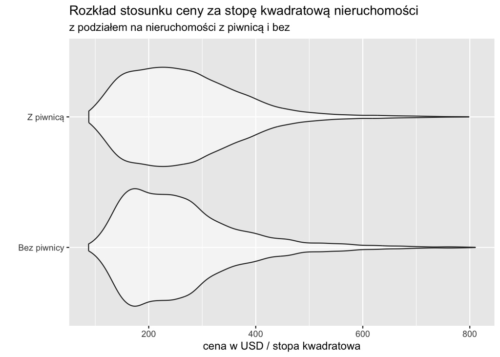

```r
# rozklad cena na dole
# powierzchnia pionowo
# z piwnicą lub bez
excercise2 <- df %>% mutate(has_basement = ifelse(sqft_basement > 0,"Z piwnicą", "Bez piwnicy"), price_per_sq_ft = price/sqft_living)
ggplot(excercise2, aes(x = price_per_sq_ft, y = has_basement)) +
  geom_violin(alpha = 0.50)  +
  labs(title = "Rozkład stosunku ceny za stopę kwadratową nieruchomości",
       subtitle = "z podziałem na nieruchomości z piwnicą i bez",
       y = "",
       x = "cena w USD / stopa kwadratowa")
```

**Komentarz:** Wniosek jest taki, że rozkłady są bardzo podobne.

## Zadanie 3

Jaka jest zależność pomiędzy jakością wykończenia nieruchomości a liczbą pięter?

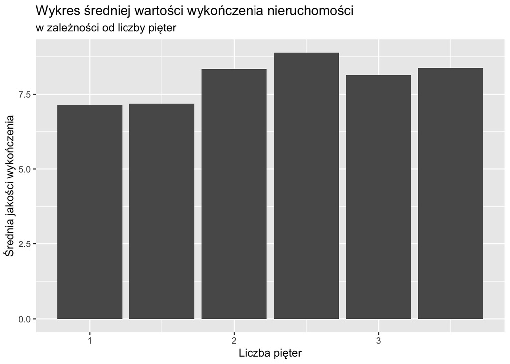

```r
excercise3 <- df %>% group_by(floors) %>% summarise(avg_grade = mean(grade, trim = 0.01)) # ucinamy anomalie trimem żeby dostać wykres na którym są lepiej widoczne różnice między piętrami.

ggplot(excercise3, aes(x=floors, y=avg_grade))  +
  labs(x = "Liczba pięter",
       y = "Średnia jakości wykończenia",
       title = "Wykres średniej wartości wykończenia nieruchomości",
       subtitle = "w zależności od liczby pięter",
       ) +
  geom_col()
```

**Komentarz:**

## Zadanie 4

Jaka jest zależność między powierzchnią mieszkalną nieruchomości a powierzchnią gruntu w podziale na liczbę sypialni?

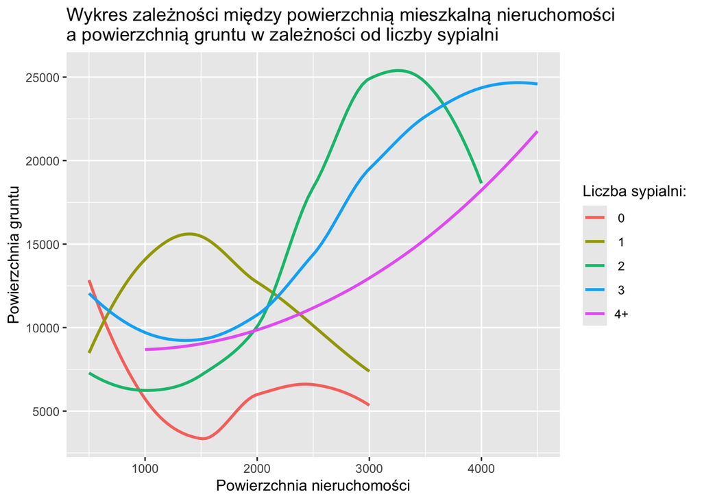

```r
excercies4a <- df  %>% select(sqft_living, sqft_lot, bedrooms)
excercies4b <- excercies4a %>% filter(sqft_lot < quantile(excercies4a[['sqft_lot']], 0.985)) %>% filter(sqft_living < quantile(excercies4a[['sqft_living']], 0.985)) %>% filter(bedrooms < 10.0) %>% mutate(bedrooms = ifelse(bedrooms < 4, paste("", bedrooms), "4+")) # wycinamy anomalia statystyczne kwantylami, oraz redukujemy liczbę kategorii ilości sypialni do 5 by poprawić czytelność wykresu
excercies4c <- excercies4b %>% mutate(sqft_living =  ((sqft_living + 250 ) %/% 500) * 500)  %>% group_by(sqft_living, bedrooms) %>% summarise(avg_sqft_lot = mean(sqft_lot))
ggplot(excercies4c, aes(x = sqft_living, y = avg_sqft_lot, color = bedrooms)) +
  labs(x = "Powierzchnia nieruchomości",
       y = "Powierzchnia gruntu",
       color = "Liczba sypialni:",
       title = "Wykres zależności między powierzchnią mieszkalną nieruchomości\na powierzchnią gruntu w zależności od liczby sypialni",
       )   + geom_smooth(method = "loess", span = 1, se=FALSE)
```

**Komentarz:**

## Zadanie 5

Rozważmy tylko nieruchomości, które miały remont. W której dekadzie było najwięcej przeprowadzonych remontów? Czy w poszczególnych dekadach jest porównywalny procent nieruchmości dla każdej wartości miary jakości i wykończenia nieruchomości?

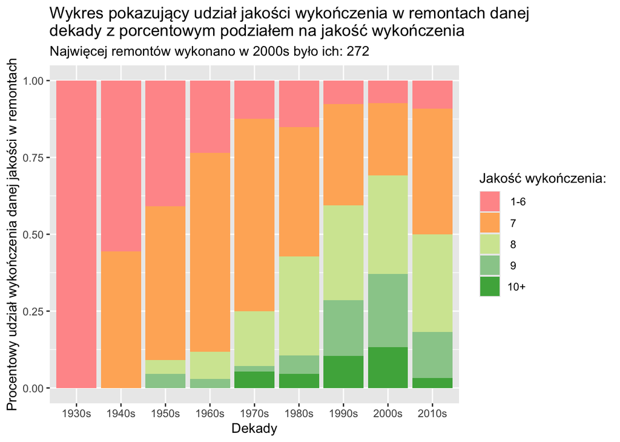

```r
ex5a <- df %>% filter(yr_renovated > 0) %>% mutate(decade = paste((yr_renovated %/%  10) * 10, "s", sep="")) %>%
  mutate(grade = ifelse(grade < 7, " 1-6", ifelse(grade > 9, "10+", paste("", grade)))) %>%
  mutate(decade = paste(decade))
ex5b <- ex5a %>% group_by(decade) %>% summarise(count = n())
max <- (ex5b %>% filter(count == max(count)))
max_decade <- max["decade"]
max_count <- max["count"]
ggplot(ex5a, aes(x = decade,  fill = grade, group = grade)) +
  labs(y = "Procentowy udział wykończenia danej jakości w remontach",
       x = "Dekady",
       fill = "Jakość wykończenia:",
       title = "Wykres pokazujący udział jakości wykończenia w remontach danej\ndekady z porcentowym podziałem na jakość wykończenia",
       subtitle = paste("Najwięcej remontów wykonano w", max_decade, "było ich:", max_count),
       ) + scale_fill_manual(values = c("#FF9999", "#FFB266", "#D2E6A1",  "#99CC99",  "#4DAF4A")) + geom_bar(stat = "count", position = "fill")
```

**Komentarz:** Jak widzimy procent nieruchmości dla każdej wartości miary jakości i wykończenia w poszczególnych dekadach nie jest porównywalny, jedynie może dla 8-ki w latach 80s-10s. Generalnie można zauważyć tendencję wzrostu jakości wykończenia na przestrzeni dekad.

## Zadanie 6

Jak prezentuje się wartość minimalna, średnia i maksymalna ceny nieruchmości w podziele na rok budowy nieruchomości.

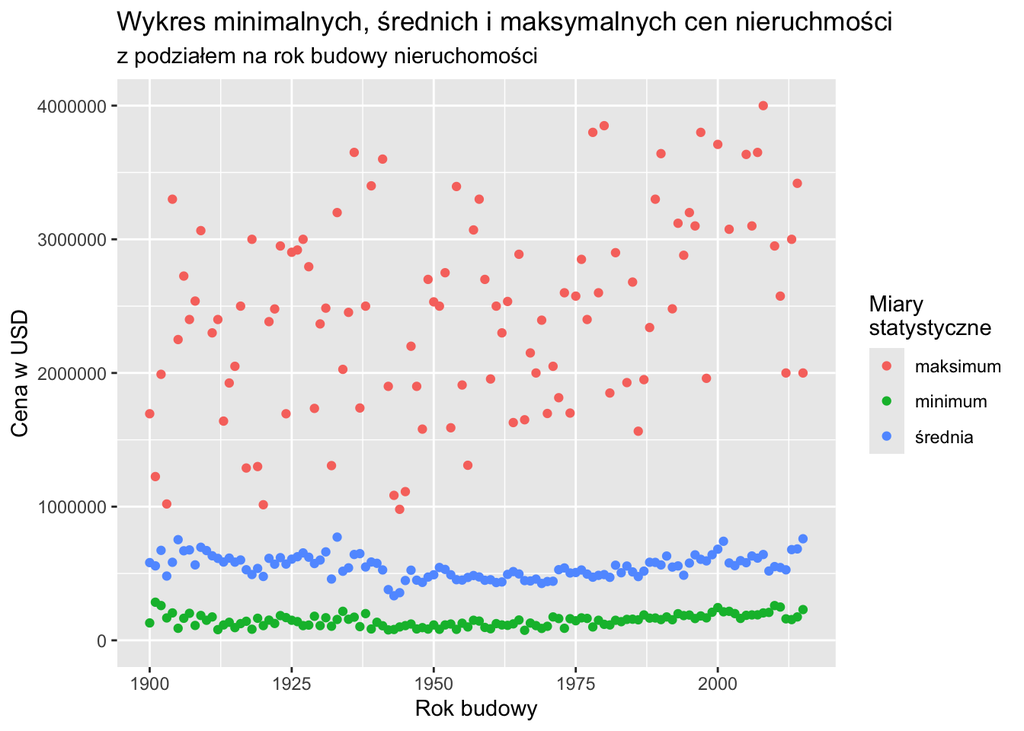

```r
ex6max <- df %>% select(price, yr_built) %>% group_by(yr_built) %>% summarise(price = max(price)) %>% mutate(category = "maksimum")
ex6min <- df %>% select(price, yr_built) %>% group_by(yr_built) %>% summarise(price = min(price)) %>% mutate(category = "minimum")
ex6avg <- df %>% select(price, yr_built) %>% group_by(yr_built) %>% summarise(price = mean(price)) %>% mutate(category = "średnia")

ex6 <- rbind(ex6max, ex6min, ex6avg)
ex6 %>% ggplot(aes(x=yr_built, y=price, color = category)) +  geom_point()  +
  labs(y = "Cena w USD",
       x = "Rok budowy",
       fill = "Jakość wykończenia:",
       title = "Wykres minimalnych, średnich i maksymalnych cen nieruchmości",
       subtitle = "z podziałem na rok budowy nieruchomości",
       color = "Miary\nstatystyczne"
       ) + ylim(0, 4000000) # wycinamy anomalia, żeby lepiej widzieć inne dane na wykresie
```

**Komentarz:** Jak widać, maksima cen mają tendencję lekko wzrostową, reszta raczej stała, przynajmniej w porównaniu do maksimów.